# MAXOUT Study Abroad

__________________________________________________________________  
Project timeline

The **MAXOUT Study Abroad** project is envisaged as a longitudinal cross-institutional mixed-methods research project. The target population is all UK undergraduates studying on a Japanese or/and Korean language/studies course that has a compulsory study abroad year or semester as part of the degree.

It aims to interview UK undergraduate students on a Japanese or Korean course at three time-points during their university and post-university careers:

- at the beginning of their *first year* of studies;
- in their *final year* of studies, following return from study abroad;
- and one year *after graduation*.

## Project timeline

The Pilot phase of the project began in the 2019/2020 academic year, with an online survey distributed between March-May 2020. Unfortunately, due to the Covid-19 pandemic, study abroad travel on all 3-year degrees was put on hold and due to the general uncertainty regarding study abroad, the project was unable to collect data as planned from all the sampled institutions, and the qualitative interview data collection was also put on hold. Most of the data originated from the then home institution of the research team members, and following a transition to 4-year degrees and a better outlook on the future containment of the pandemic, a new cohort (from a single post-1992 university) was surveyed in October 2020, and qualitative interview data on a smaller selected sample of the respondents was also collected.

These two cohorts make up the single-institution pilot phase of the project, and in the 2023/2024 academic year Cohort P2 students (the first post-pandemic student cohort to have taken part in study abroad in their third year of studies on a 4-year degree) also returned from study abroad, making possible the first post-SA data collection round.

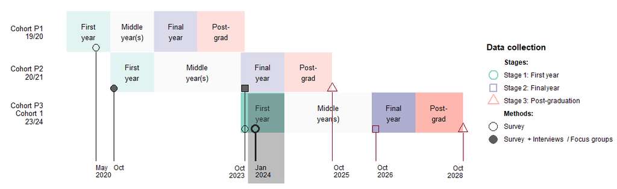

Fig. 1: MAXOUT data collection timeline

A funding application is made to implement the first cross-institutional first-year (pre-SA) cohort survey (MAXOUT-SA 1.1.1). This will enable the research team to address the body of research questions that aims to investigate the connections between social mobility and international student mobility on a nationally representative sample. The project cross-section for which funding is sought is highlighted in light grey in the chart below.

## Subproject naming convention

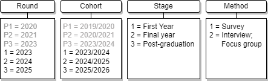

Fig. 2: Project component naming convention